# Aesthetics

Edneide Ramalho

11 Fevereiro, 2022

# 1 Exercícios

## 1.1 All about aesthetics: color, shape and size

In the video you saw 9 visible aesthetics. Let’s apply them to a categorical variable — the cylinders in `mtcars`, `cyl`.

These are the aesthetics you can consider within [**`aes()`**](http://www.rdocumentation.org/packages/ggplot2/functions/aes) in this chapter: `x`, `y`, `color`, `fill`, `size`, `alpha`, `labels` and `shape`.

One common convention is that you don’t name the `x` and `y` arguments to `aes()`, since they almost always come first, but you do name other arguments.

In the following exercise the `fcyl` column is categorical. It is `cyl` transformed into a `factor`.

```r
library(tidyverse)
mtcars %>% glimpse()
```

```
## Rows: 32
## Columns: 11
## $ mpg  <dbl> 21.0, 21.0, 22.8, 21.4, 18.7, 18.1, 14.3, 24.4, 22.8, 19.2, 17.8,…
## $ cyl  <dbl> 6, 6, 4, 6, 8, 6, 8, 4, 4, 6, 6, 8, 8, 8, 8, 8, 8, 4, 4, 4, 4, 8,…
## $ disp <dbl> 160.0, 160.0, 108.0, 258.0, 360.0, 225.0, 360.0, 146.7, 140.8, 16…
## $ hp   <dbl> 110, 110, 93, 110, 175, 105, 245, 62, 95, 123, 123, 180, 180, 180…
## $ drat <dbl> 3.90, 3.90, 3.85, 3.08, 3.15, 2.76, 3.21, 3.69, 3.92, 3.92, 3.92,…
## $ wt   <dbl> 2.620, 2.875, 2.320, 3.215, 3.440, 3.460, 3.570, 3.190, 3.150, 3.…
## $ qsec <dbl> 16.46, 17.02, 18.61, 19.44, 17.02, 20.22, 15.84, 20.00, 22.90, 18…
## $ vs   <dbl> 0, 0, 1, 1, 0, 1, 0, 1, 1, 1, 1, 0, 0, 0, 0, 0, 0, 1, 1, 1, 1, 0,…
## $ am   <dbl> 1, 1, 1, 0, 0, 0, 0, 0, 0, 0, 0, 0, 0, 0, 0, 0, 0, 1, 1, 1, 0, 0,…
## $ gear <dbl> 4, 4, 4, 3, 3, 3, 3, 4, 4, 4, 4, 3, 3, 3, 3, 3, 3, 4, 4, 4, 3, 3,…
## $ carb <dbl> 4, 4, 1, 1, 2, 1, 4, 2, 2, 4, 4, 3, 3, 3, 4, 4, 4, 1, 2, 1, 1, 2,…
```

```r
data <- mtcars %>%
  dplyr::mutate(fcyl = factor(cyl),
                fam = factor(am))
```

- Map `mpg` onto the `x` aesthetic, and `fcyl` onto the `y`.

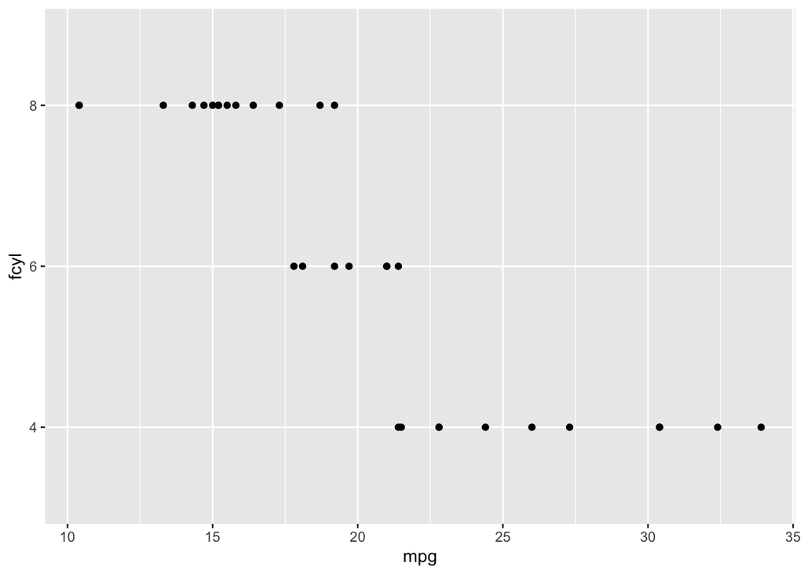

```r
# Map x to mpg and y to fcyl
ggplot(data, aes(mpg, fcyl)) +
  geom_point()
```

- Swap the mappings of the first plot: `fcyl` onto the `x` aesthetic, and `mpg` onto the `y`.

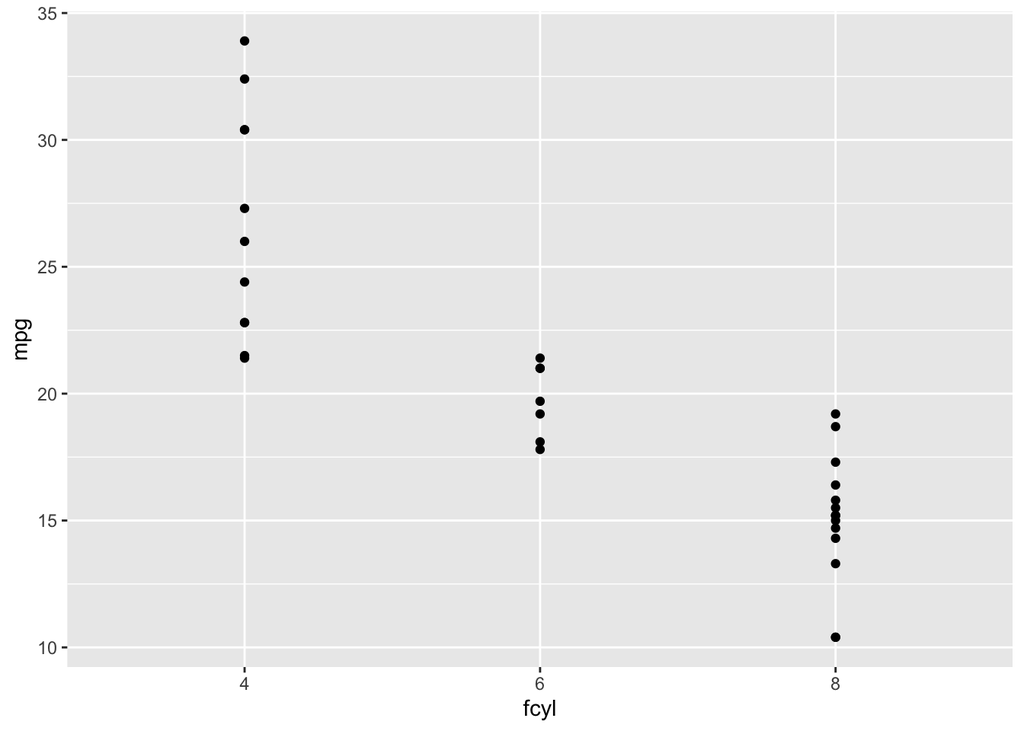

```r
# Swap mpg and fcyl
ggplot(data, aes(fcyl, mpg)) +
  geom_point()
```

- Map `wt` onto `x`, `mpg` onto `y`, and `fcyl` onto `color`.

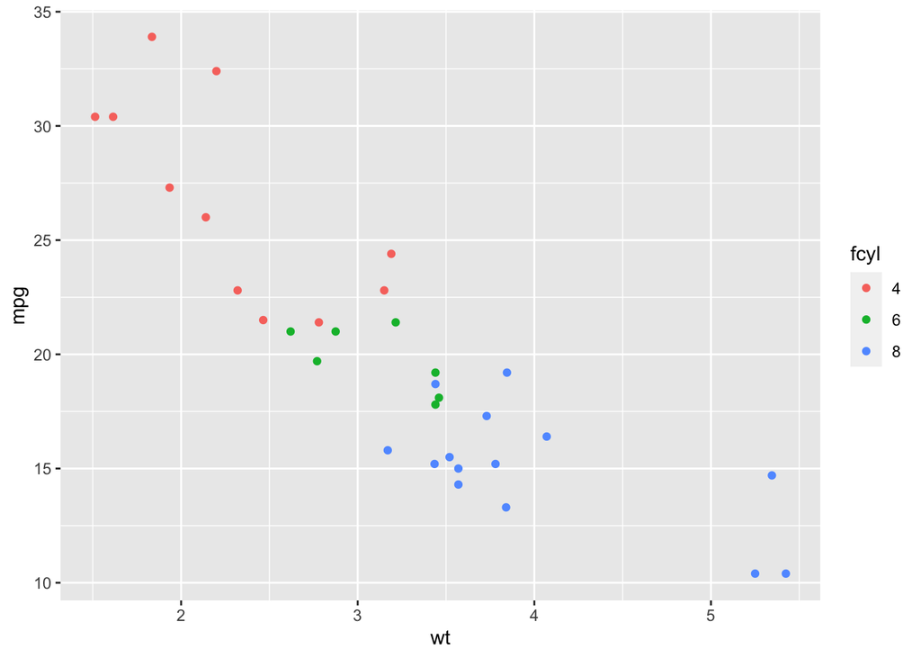

```r
# Map x to wt, y to mpg and color to fcyl
ggplot(data, aes(wt, mpg, color = fcyl)) +
  geom_point()
```

- Modify the point layer of the previous plot by changing the `shape` argument to `1` and increasing the `size` to `4`.

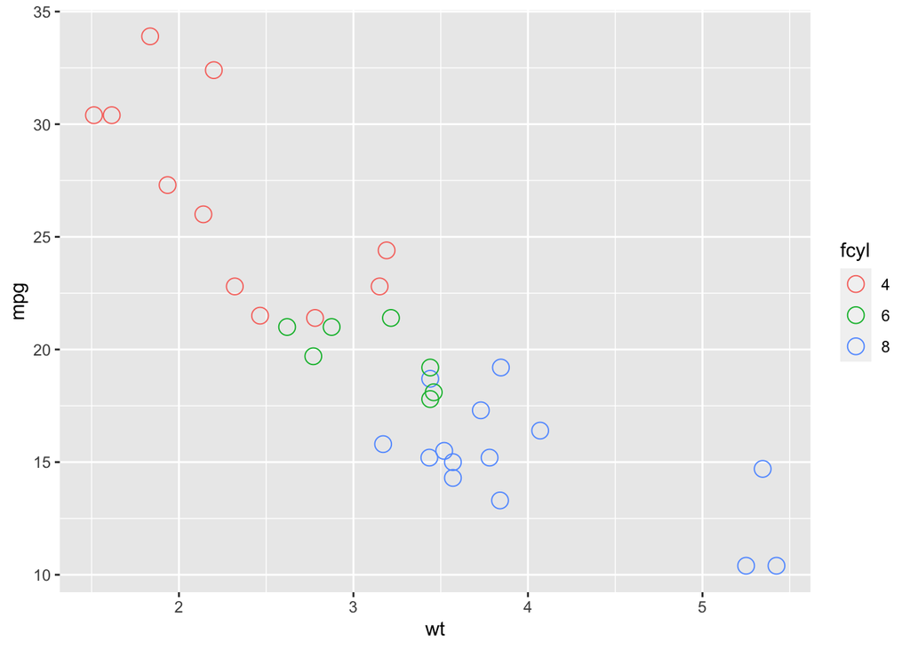

```r
ggplot(data, aes(wt, mpg, color = fcyl)) +
  # Set the shape and size of the points
  geom_point(shape = 1, size = 4)
```

## 1.2 All about aesthetics: color vs. fill

Typically, the `color` aesthetic changes the *outline* of a geom and the `fill` aesthetic changes the *inside*. `geom_point()` is an exception: you use `color` (not `fill`) for the point color. However, some shapes have special behavior.

The default `geom_point()` uses `shape = 19`: a solid circle. An alternative is `shape = 21`: a circle that allow you to use *both* `fill` for the inside *and* `color` for the outline. This is lets you to map two aesthetics to each point.

All shape values are described on the [**`points()`**](https://www.rdocumentation.org/packages/graphics/topics/points) help page.

`fcyl` and `fam` are the `cyl` and `am` columns converted to factors, respectively.

- Change the aesthetics so that `fcyl` maps to `fill` rather than `color`.

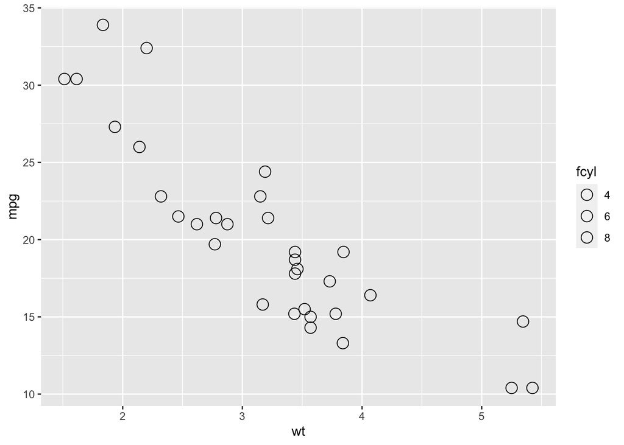

```r
# Map fcyl to fill
ggplot(data, aes(wt, mpg, fill = fcyl)) +
  geom_point(shape = 1, size = 4)
```

- In `geom_point()` change the `shape` argument to `21` and add an `alpha` argument set to `0.6`.

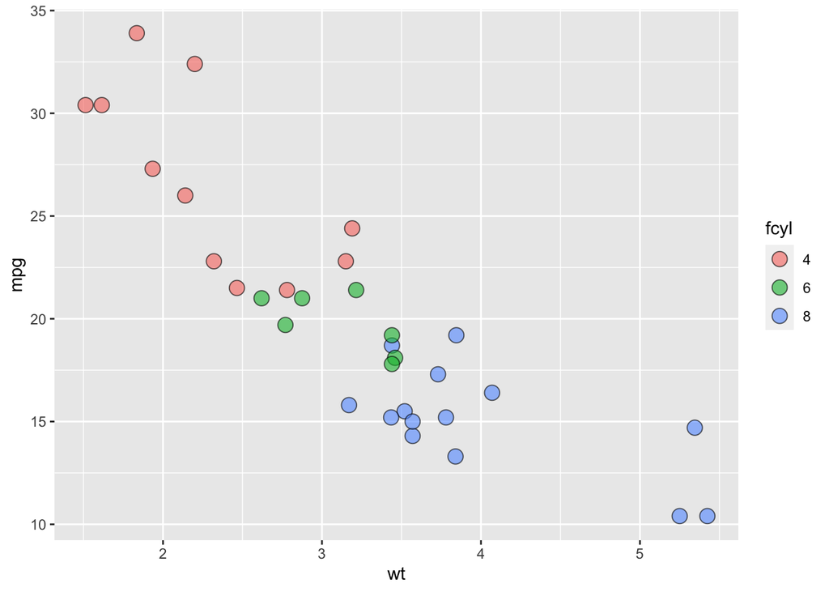

```r
ggplot(data, aes(wt, mpg, fill = fcyl)) +
  # Change point shape; set alpha
  geom_point(shape = 21, size = 4, alpha = 0.6)
```

- In the `ggplot()` aesthetics, map `fam` to `color`.

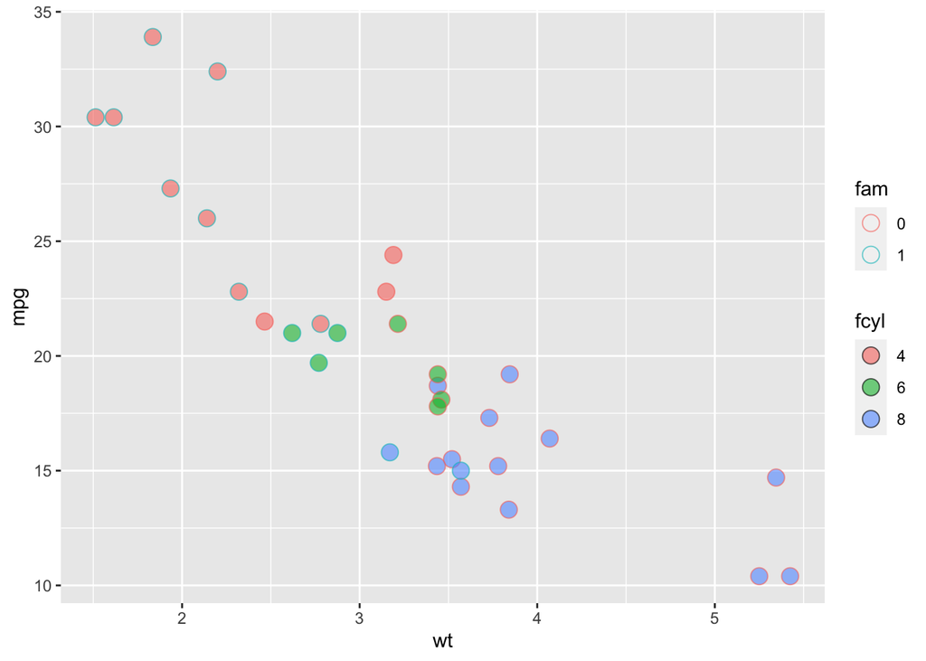

```r
# Map color to fam
ggplot(data, aes(wt, mpg, fill = fcyl, color = fam)) +
  geom_point(shape = 21, size = 4, alpha = 0.6)
```

## 1.3 All about aesthetics: comparing aesthetics

Now that you’ve got some practice with using attributes, be careful of a major pitfall: these attributes can overwrite the aesthetics of your plot!

- Using `mtcars`, create a plot base layer, `plt_mpg_vs_wt`. Map `mpg` onto `y` and `wt` onto `x`.
- Add a point layer, mapping the categorical no. of cylinders, `fcyl`, onto `size`.

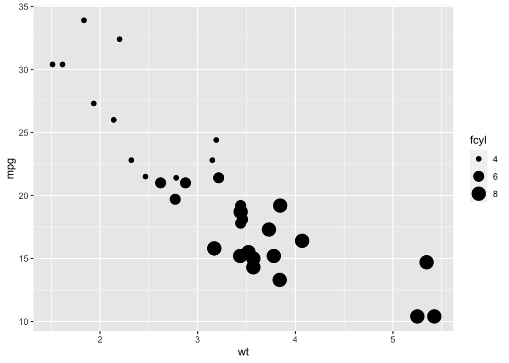

```r
# Establish the base layer
plt_mpg_vs_wt <- ggplot(data, aes(wt, mpg))

# Map fcyl to size
plt_mpg_vs_wt +
  geom_point(aes(size = fcyl))
```

- Change the mapping. This time `fcyl` should be mapped onto `alpha`.

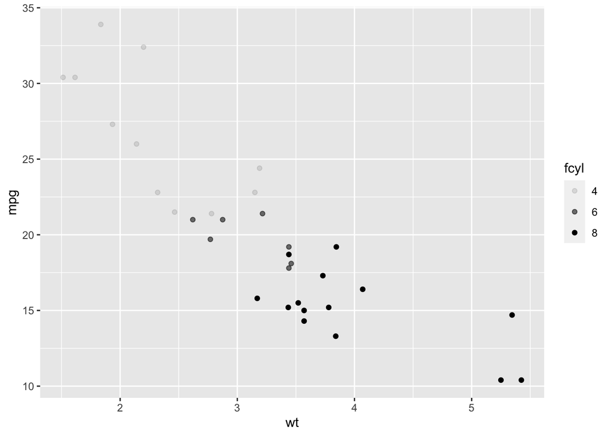

```r
plt_mpg_vs_wt +
  geom_point(aes(alpha = fcyl))
```

- Change the mapping again. This time `fycl` should be mapped onto `shape`.

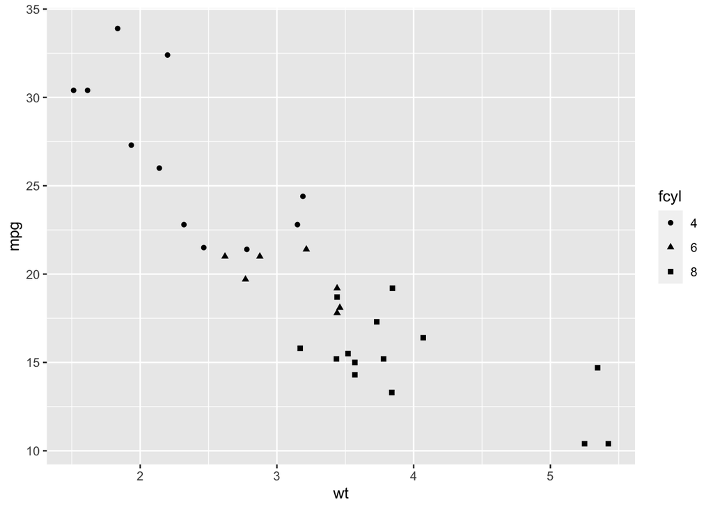

```r
plt_mpg_vs_wt +
  geom_point(aes(shape = fcyl))
```

- Swap the geom layer: change points to text.
- Change the mapping again. This time `fycl` should be mapped onto `label`.

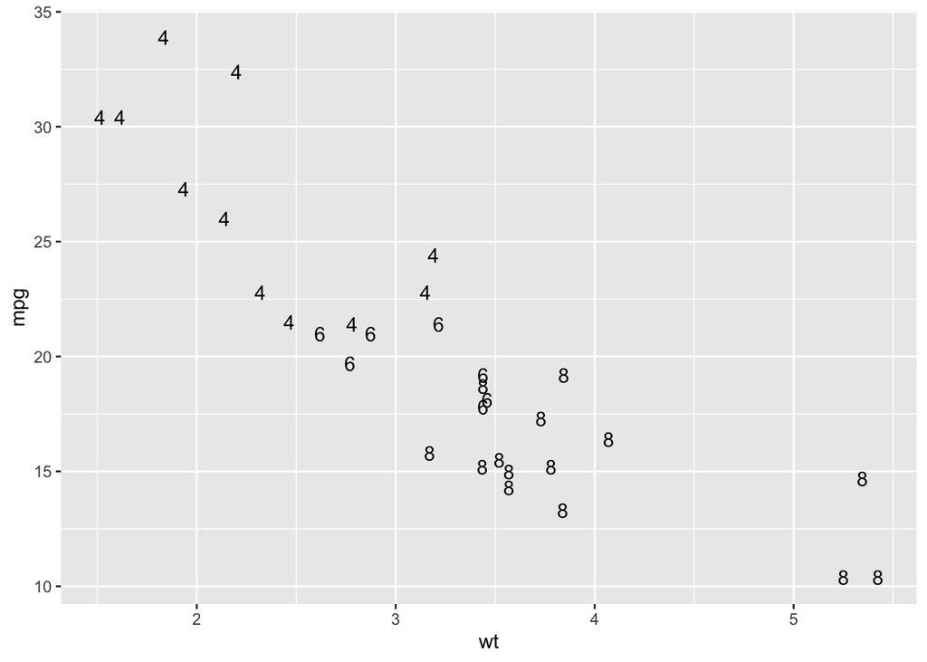

```r
plt_mpg_vs_wt +
  geom_text(aes(label = fcyl))
```

- `label` e `shape` só são aplicadas a dados categóricos.

# 2 Usando atributos

- Os atributos vão sempre na camada da `geom`

## 2.1 Exercícios

### 2.1.1 All about attributes: color, shape, size and alpha

This time you’ll use these arguments to set *attributes* of the plot, not map variables onto *aesthetics*.

You can specify colors in R using **hex codes**: a hash followed by two hexadecimal numbers each for red, green, and blue (`"#RRGGBB"`). Hexadecimal is base-16 counting. You have 0 to 9, and A representing 10 up to F representing 15. Pairs of hexadecimal numbers give you a range from 0 to 255. `"#000000"` is “black” (no color), `"#FFFFFF"` means “white”, and `“#00FFFF” is cyan (mixed green and blue).

A hexadecimal color variable, `my_blue` has been defined for you.

- Set the point color to `my_blue` and the alpha to `0.6`.

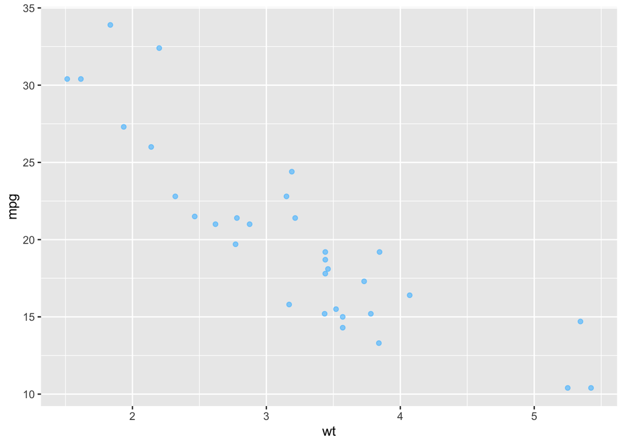

```r
# A hexadecimal color
my_blue <- "#4ABEFF"

ggplot(mtcars, aes(wt, mpg)) +
  # Set the point color and alpha
  geom_point(color = my_blue, alpha = 0.6)
```

- Change the `color` mapping to a `fill` mapping. That is, `fcyl` should be mapped onto `fill`.
- Set the `color` of the points to `my_blue`, point `size` to `10` and the point `shape` to `1`.

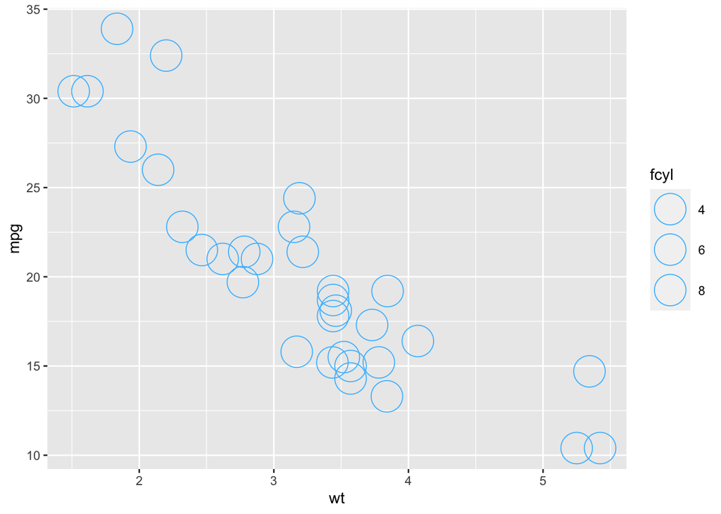

```r
# Change the color mapping to a fill mapping
ggplot(data, aes(wt, mpg, fill = fcyl)) +
  # Set point size and shape
  geom_point(color = my_blue, size = 10, shape = 1)
```

### 2.1.2 All about attributes: conflicts with aesthetics

In the videos you saw that you can use all the aesthetics as attributes. Let’s see how this works with the aesthetics you used in the previous exercises: `x`, `y`, `color`, `fill`, `size`, `alpha`, `label` and `shape`.

In this exercise you will set all kinds of attributes of the points!

You will continue to work with `mtcars`.

- Add a point layer, setting `alpha`, the transparency, to `0.5`.

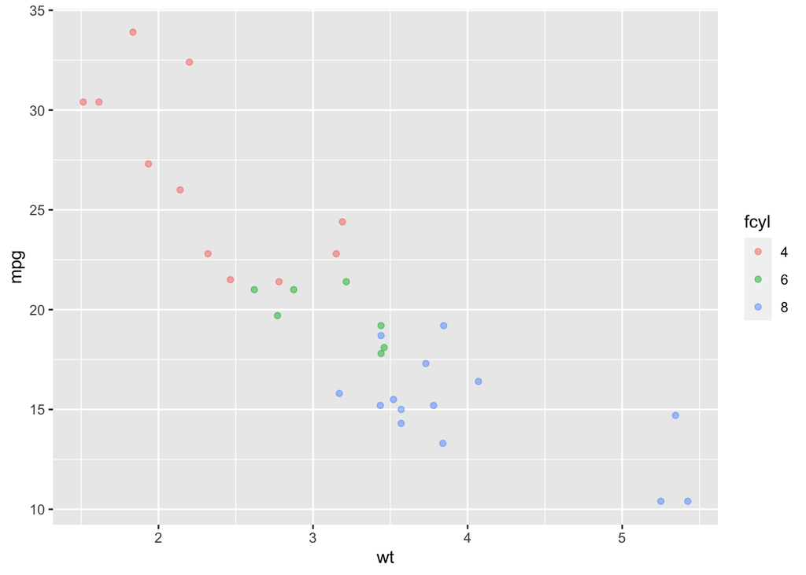

```r
ggplot(data, aes(wt, mpg, color = fcyl)) +
  # Add point layer with alpha 0.5
  geom_point(alpha = 0.5)
```

- Add a text layer, setting the `label` to the rownames of the dataset `mtcars`, and the `color` to `"red"`.

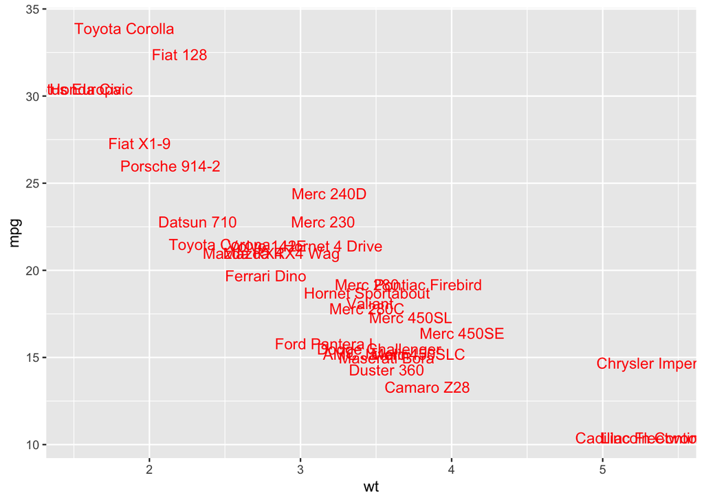

```r
ggplot(data, aes(wt, mpg, color = fcyl)) +
  # Add point layer with alpha 0.5
  geom_text(label = rownames(data), color = "red")
```

- Add a point layer, setting the `shape` to `24` and the `color` to `"yellow"`.

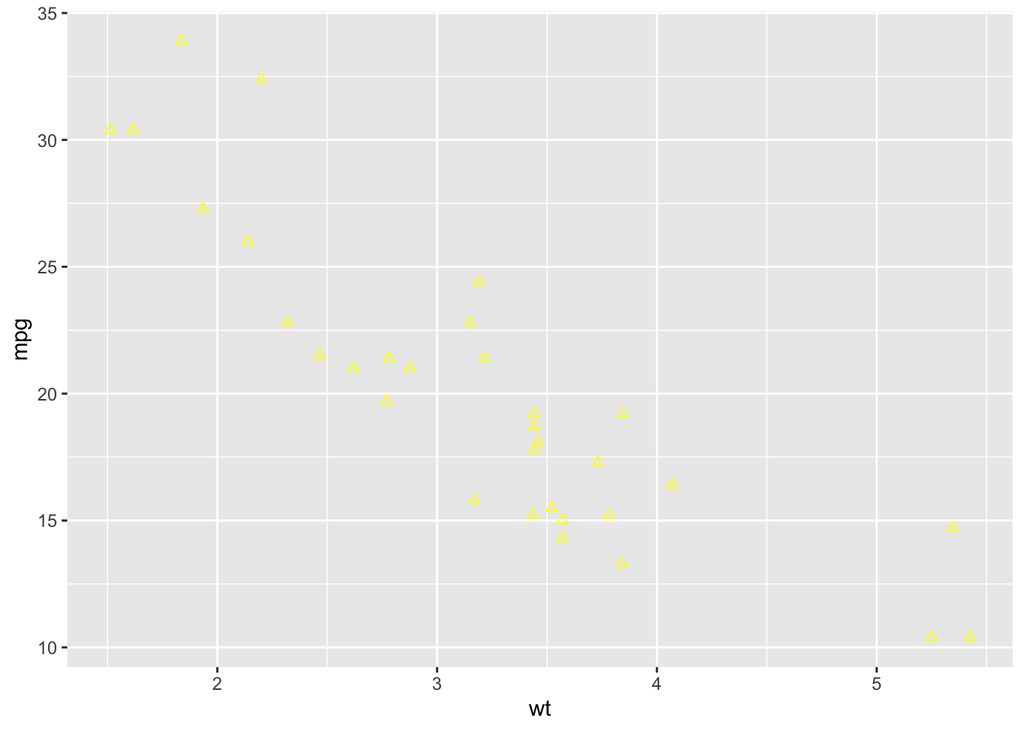

```r
ggplot(data, aes(wt, mpg, color = fcyl)) +
  # Add points layer with shape 24 and color yellow
  geom_point(shape = 24, color = "yellow")
```

### 2.1.3 Going all out

In this exercise, you will gradually add more aesthetics layers to the plot. You’re still working with the `mtcars` dataset, but this time you’re using more features of the cars. Each of the columns is described on the [**`mtcars`**](https://www.rdocumentation.org/packages/datasets/topics/mtcars) help page. Columns `fcyl` and `fam` have been added (as before) as categorical versions of `cyl` and `am` respectively.

Notice that adding more aesthetic mappings to your plot is not always a good idea! You may just increase complexity and decrease readability.

- Use `mtcars` to draw a plot of `qsec` vs. `mpg`, colored by `fcyl`.
- Add a point layer.

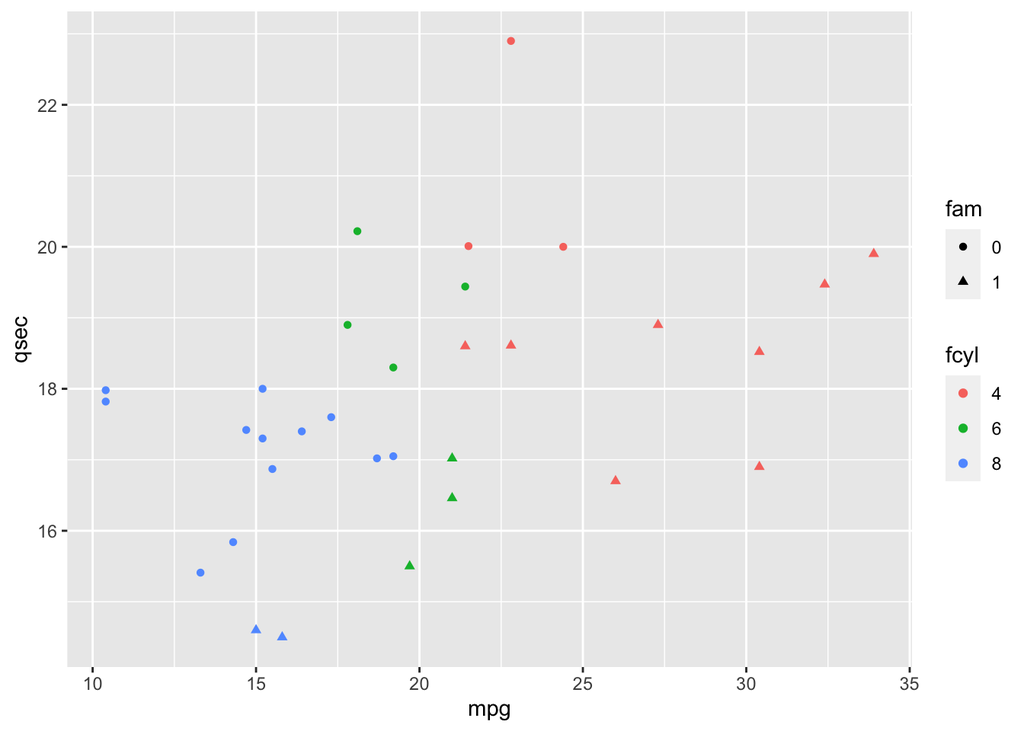

```r
ggplot(data, aes(mpg, qsec, color = fcyl, shape = fam)) +
  geom_point()
```

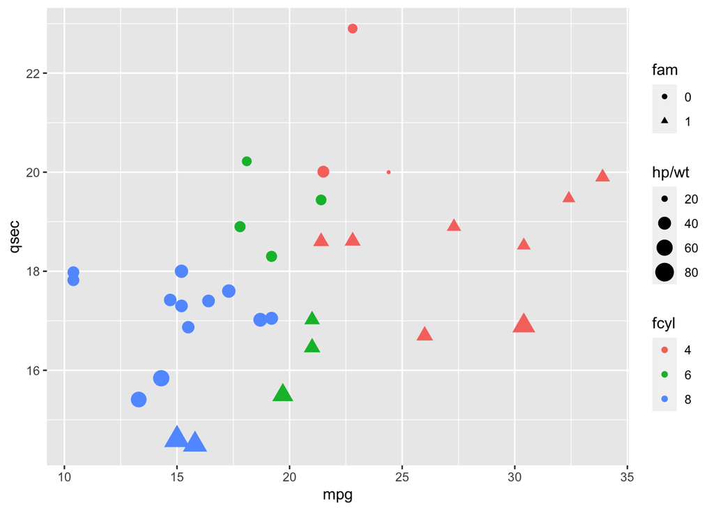

```r
ggplot(data, aes(mpg, qsec, color = fcyl, shape = fam, size = hp/wt)) +
  geom_point()
```

# 3 Modifying Aesthetics